# DataMining_BackPain_Project

# 3. EDA (EXPLORATORY DATA ANALYSIS)

```r
glimpse(TrainSet)
```

```
## Observations: 275
## Variables: 32
## $ PainDiagnosis   <fct> Nociceptive, Neuropathic, Nociceptive, Neuropa...
## $ Age             <dbl> 34, 53, 45, 41, 32, 49, 54, 42, 29, 54, 25, 47...
## $ Gender          <fct> Female, Female, Female, Male, Female, Male, Ma...
## $ DurationCurrent <fct> 7-12 months, > 1 year, > 1 year, 4-6 weeks, 7-...
## $ PainLocation    <fct> Back, Back + Uni Leg, Back, Uni BK, Back, Back...
## $ SurityRating    <dbl> 9, 7, 9, 9, 9, 6, 9, 9, 6, 9, 9, 8, 8, 9, 10, ...
## $ RMDQ            <dbl> 15, 9, 10, 21, 14, 5, 1, 12, 12, 14, 14, 6, 14...
## $ vNRS            <dbl> 8.5, 3.0, 4.5, 8.0, 4.0, 1.0, 5.0, 5.5, 5.0, 5...
## $ SF36PCS         <dbl> 29.6, 41.9, 33.1, 21.2, 19.4, 28.4, 43.7, 42.4...
## $ SF36MCS         <dbl> 46.0, 35.3, 28.4, 27.2, 53.9, 34.6, 51.2, 44.5...
## $ PF              <dbl> 27.6, 42.3, 23.4, 17.0, 29.7, 44.4, 48.6, 46.5...
## $ BP              <dbl> 29.2, 37.2, 33.0, 19.9, 29.2, 19.9, 37.2, 24.9...
## $ GH              <dbl> 43.4, 43.4, 32.9, 36.2, 28.1, 28.1, 45.8, 59.1...
```

[output cut: 19 more lines]

Performing the Exploratory Data Analysis would help us to understand more about the dataset we are working with. There are 2 types of Data which are Numeric and Categorical in the dataset. We want to look into the set of Numerical and set of Categorical separately to see if the datatype of all variables make sense. In other words, I maybe miss-typed if the categorical data has too many levels.

```r
Num_Var <- unlist(lapply(TrainSet, is.numeric))
Cat_Var <-  unlist(lapply(TrainSet, is.factor))
```

- The chunk of code above is to separate the numerical variables and categorical variables into 2 subsets.

```r
str(TrainSet[,Cat_Var])
```

```
## 'data.frame':    275 obs. of  19 variables:
##  $ PainDiagnosis  : Factor w/ 2 levels "Nociceptive",..: 1 2 1 2 1 1 1 2 2 1 ...
##  $ Gender         : Factor w/ 2 levels "Female","Male": 1 1 1 2 1 2 2 2 1 1 ...
##  $ DurationCurrent: Factor w/ 6 levels "0-3 weeks","4-6 weeks",..: 5 6 6 2 3 6 4 1 4 3 ...
##  $ PainLocation   : Factor w/ 6 levels "Back","Back+Thigh",..: 1 5 1 3 1 1 1 3 2 1 ...
##  $ Criterion2     : Factor w/ 2 levels "Absent","Present": 2 2 2 2 2 2 2 2 2 2 ...
##  $ Criterion4     : Factor w/ 2 levels "Absent","Present": 1 1 1 1 1 1 1 1 1 1 ...
##  $ Criterion6     : Factor w/ 2 levels "Absent","Present": 1 1 1 1 1 1 1 1 1 1 ...
##  $ Criterion7     : Factor w/ 2 levels "Absent","Present": 1 2 1 2 1 1 1 2 1 1 ...
##  $ Criterion8     : Factor w/ 2 levels "Absent","Present": 2 1 2 1 2 2 2 1 1 2 ...
##  $ Criterion9     : Factor w/ 2 levels "Absent","Present": 1 2 1 2 1 1 1 2 2 1 ...
##  $ Criterion10    : Factor w/ 2 levels "Absent","Present": 1 1 1 1 1 1 1 1 1 1 ...
##  $ Criterion13    : Factor w/ 2 levels "Absent","Present": 1 1 1 1 1 1 1 1 1 1 ...
##  $ Criterion19    : Factor w/ 2 levels "Absent","Present": 1 2 2 2 1 2 2 2 1 1 ...
##  $ Criterion20    : Factor w/ 2 levels "Absent","Present": 2 2 2 2 2 2 2 1 2 2 ...
##  $ Criterion26    : Factor w/ 2 levels "Absent","Present": 1 1 1 2 1 1 1 1 1 1 ...
##  $ Criterion28    : Factor w/ 2 levels "Absent","Present": 2 2 2 2 2 2 2 2 2 2 ...
##  $ Criterion32    : Factor w/ 2 levels "Absent","Present": 2 1 2 1 2 2 2 1 1 2 ...
##  $ Criterion33    : Factor w/ 2 levels "Absent","Present": 1 1 1 1 1 1 1 1 1 1 ...
##  $ Criterion36    : Factor w/ 2 levels "Absent","Present": 1 1 1 1 1 1 1 1 1 1 ...
```

#### Correlation Plot of Numeric Variable

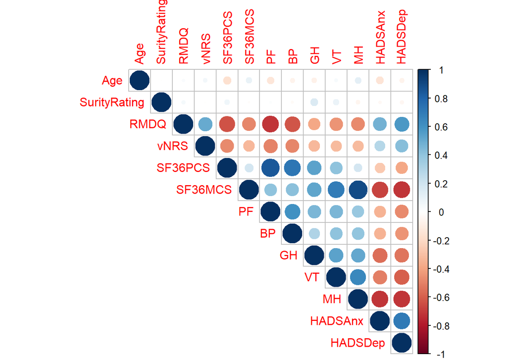

```r
corrplot(cor(TrainSet[,Num_Var]), method="circle", type= "upper")
```

Some of numeric variables have very strong correlation (Pearson type), this is a strong indication of using PCA to pre-process data in later steps.

```r
prop.table(table(TrainSet$PainDiagnosis))
```

```
##
## Nociceptive Neuropathic
##   0.5454545   0.4545455
```

The ratio of 2 levels of response variable (Nociceptive and Neuropathic) is quite balanced in Train Data. We do not need to worry about Imbalanced Data in this Dataset.